# Phy 481 HW 3

## 1. Ring of charge

We'll use spherical coordinates

(1) Drawing

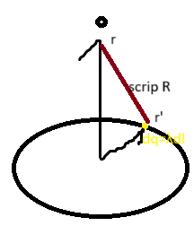

(2)

$$ \vec r = z \hat z \\ \vec r' = R \hat s \\ \text{script r }\vec{\mathcal{R}} = z \hat z - R \hat s \\ \hat{\mathcal{R}} = \frac{z \hat z - R \hat s}{\sqrt{z^2+R^2}} \\ dl = R d \theta $$

(3) Z is common between the two $$ \hat{\mathcal{R}} = \frac{z\hat{z} - R(\cos\theta \hat x + \sin\theta \hat y)}{\sqrt{z^2+R^2}} $$

(4) $$ \vec E = k \int \frac{\lambda}{\mathcal{R}^2} \hat{\mathcal{R}} dl \\ = \lambda k \int \frac{z \hat z - R(\cos \theta \hat x + \sin \theta \hat y)}{\left( z^2 + R^2 \right)^{3/2}}Rd\theta $$

(5) For $x$ and $y$ the integral evaluates to 0 since there is a $\cos$ or $\sin$ term that evaluates to zero when integrated across the domain. This makes sense physically since each charge has an opposite at -x, -y

$$ E_z = k\lambda \frac{zR}{\left(z^2+R^2\right)^{3/2}} \int_0^{2\pi} d\theta \\ = \frac{1}{4\pi\epsilon_0}\frac{\lambda zR * 2\pi}{(z^2 + R^2)^{3/2}} $$

## 2. Checking result

(1) dimensional analysis $$ \frac{1}{4\pi\epsilon_0} = \frac{Nm^2}{C^2} \\ \lambda = \frac{C}{m}\\ [Nm^2C^{-2}][Cm^{-1}][m^2][m^{-3}]=[NC^{-1}]=\frac{N}{C} $$

(2)

Z=0 should be zero according to argument from question 1.5, since there is no z-component and x/y components cancel themselves.

Z>>R=0 since electric field decays to zero with long distances

(3)

$Z=0$: $$ E = \frac{\lambda 2\pi R}{4\pi \epsilon_0} \frac{z}{\left(z^2 + R^2\right)^{3/2}} $$ Approaches $0/R^3 \checkmark$

$Z>>R$: $$ E = \frac{\lambda 2\pi R}{4\pi \epsilon_0} \frac{z}{\left(z^2 + R^2\right)^{3/2}} \approx \frac{\lambda 2\pi R}{4\pi \epsilon_0} \frac{z}{\left(z^2\right)^{3/2}} \frac{\lambda 2\pi R}{4\pi \epsilon_0} \frac{z}{z^3} $$

Which goes to $0/z^2$ as $z\rightarrow \infty$

Since these checks align with my expectations I believe this is the correct answer

## 3. Disk of charge.

(1) Use same formulas only with area integral and $s$ instead of $R$

$$ \vec r' = s'\hat s = -s'\cos\theta \hat x - s' \sin\theta \hat y\\ \mathcal{R} = z \hat z -s'\cos\theta \hat x - s' \sin\theta \hat y \\ E = k \int_0^{2\pi}\int_0^{R} (-\sigma )\left( \frac{\mathcal{R}}{|\mathcal{R}|^3}\right) s ds d\theta \\ = -k\sigma \int_0^{2\pi}\int_0^{R} \left( \frac{z \hat z -s'\cos\theta \hat x - s' \sin\theta \hat y}{\left(z^2+s^2\right)^{3/2}}\right) s ds d\theta $$ Consider only $E_z$ since $\cos$ and $\sin$ terms go to zero when integrating $0$ to $2\pi$

$$ E_z = -k\sigma \int_0^{R} \frac{zs ds}{(z^2+s^2)^{3/2}} * 2\pi $$ By the power of looking up integrals, we have $$ \int_0^{R} \frac{zs ds}{(z^2+s^2)^{3/2}} = -\left.\frac{z}{\sqrt{z^2+s^2}}\right|_0^R = \frac{z}{\sqrt{z^2}} - \frac{z}{\sqrt{R^2+Z^2}} $$

$$ E(z) = -\frac{\sigma}{2\epsilon_0}\left(\frac{z}{|z|} - \frac{z}{\sqrt{R^2+Z^2}} \right) \hat z $$

(2) $z>>R$

$$ E(z) \approx \frac{z}{|z|} - \frac{z}{z\sqrt{\frac{R^2}{z^2+1}}}\\ = 1-\frac{1}{\sqrt{\frac{R^2}{z^2}+1}} = \frac{\sqrt{\frac{R^2}{z^2}+1}-1}{\sqrt{\frac{R^2}{z^2}+1}}\\ \frac{1}{z^2} \rightarrow 0 \\ E(z) \approx \frac{\sqrt{0+1}-1}{0+1} = 1-1 =0 $$

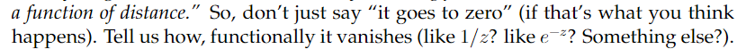

This function isn't exactly pretty, but I know for a fact the answer should be something along the lines of $\frac{1}{z^2}$ since it should become a point charge as $R$ becomes small with respect to $z$

(3) $z \rightarrow 0$

$$ E(z\rightarrow 0) \approx \frac{z}{|z|} - \frac{z}{\sqrt{R^2}} \\ \rightarrow \approx 1 - \frac{z}{r} $$

Since $-\frac{\sigma}{2\epsilon_0}$ is our result for a flat infinite field and $z/R$ goes to zero, the disk should look like an infinite field to the observation point and have an even, constant field

(4)

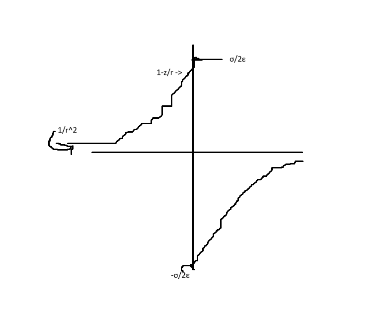

ak_HW3_Calculate_Electric_Field.ipynb